# Model-based multivariate analysis using mvabund

David Warton

Prepared for Skills-Building Day at the Eco-Stats ’15 conference.

In this lab we will use the latest version of the mvabund package (3.11.5) available on CRAN. So start by downloading it:

```r
#install.packages("mvabund", repos="https://cran.rstudio.com/") # get 3.11.5, on CRAN soon
library(mvabund)
```

In particular we will focus on hypothesis testing for count and presene-absence data, assumption checking, and trait modelling.

### What does mvabund do?

Analyse multivariate data (especially abundance or presence-absence data) using simultaneous univariate models and design-based inference. Designed specially for multivariate abundance data in ecology, species-by-site stuff, which has two key properties that need to be dealt with:

1. strong mean-variance relationship.
2. correlation between response variables (e.g. due to species interaction)

The main functions are:

- `manyglm`, which fits a GLM to each response variable (but only for a few combinations of distribution and link function)
- `traitglm`, which fits a single GLM to all abundances as a function of environmental variables and species traits, a “fourth corner model”.
- `anova`/`summary`, which use row-resampling for valid multivariate inference (i.e. taking into account correlation between variables)
- `manyany`, which will fit (in principle) any type of model (e.g. glm with and family/link function) which can then be resampled via anova Note that while `manyglm` is OK for speed, `traitglm` and `manyany` can be very slow :(

### Why not just use PRIMER, PC-ORD, etc?

A few reasons:

- To deal with property (1) as well as (2). Previous methods don’t take (1) seriously enough and (at best) try to transform the problem away. This doesn’t work when you have lots of zeros.
- Some important ecological questions imply a model, so you need a model to answer them properly. e.g. the study of composition, interactions, random effects…
- This all means better statistical properties (good power and valid Type I for more problems)
- Interpretability… when using models your assumptions are explicitly stated, parameters in your model have explicit meaning. Multivariate stuff is always hard to interpret, we need methods that are more interpretable to make some sense of what is going on.
- Flexibility… can be generalised to handle all sorts of different problems (different data types, different questions). eg use an offset to account for changes in sampling intensity
- Diagnostics… really you need to always look at your data and use it to check if the analysis you did was right for your data. This is easier with models like GLMs where your assumptions are clear and many assumption-checking tools are established.
- and more…

But mvabund is far from perfect, a few downsides:

- It is usually slower, although for big datasets (with many observations) it can be faster (it scales linearly with observations not quadratically).
- In some respects there is less functionality (e.g. no ordination function at the moment, although that will happen in 2016). Over time this is expected to change.
- GLMs aren’t perfect, there are some traps for young players. Like using summary on pres/abs data, can give weird answers (Wald statistics can be weird). When in doubt, anova is safer.

# Example - Tikus Islands data

We will use the Tikus Islands coral data. Ten transects were sampled repeatedly over several years and we are interested in studying how things change over time (in particular, after an el Nino event between the 1981 and 1983 samples). Abundance was recorded separately for each coral species, by using a 10 metre long transect and measuring the length of the transect that passed over each species of coral.

```r
data(tikus)
dat = tikus$abund[1:20,] #subset to the first 20 rows only
time = factor(tikus$x$time[1:20]) # a factor telling us the year of sampling
id = factor(tikus$x$rep[1:20]) # a factor telling us the transect that was sampled
sm  = apply(dat>0,2,sum)
dat = dat[,sm>3] #only keep variables with more than three non-zeros
coverDat = mvabund(dat) #this line is needed so R knows to treat this as multivariate abundances
```

You don’t have to remove the singletons/doubletons/tripletons, but these are almost never informative, slow down the analysis and occasionally cause problems (non-convergence etc).

Now plot the data

```
## Overlapping points were shifted along the y-axis to make them visible.
## Only the variables Heliopora.coerulea, Montipora.digitata, Favites.abdita, Favites.chinensis, Platygyra.daedalea, Montipora.foliosa, Pocillopora.damicornis, Acropora.cytherea, Acropora.hyacinthus, Acropora.formosa, Pocillopora.verrucosa, Acropora.pulchra were included in the plot
## (the variables with highest total abundance).
```

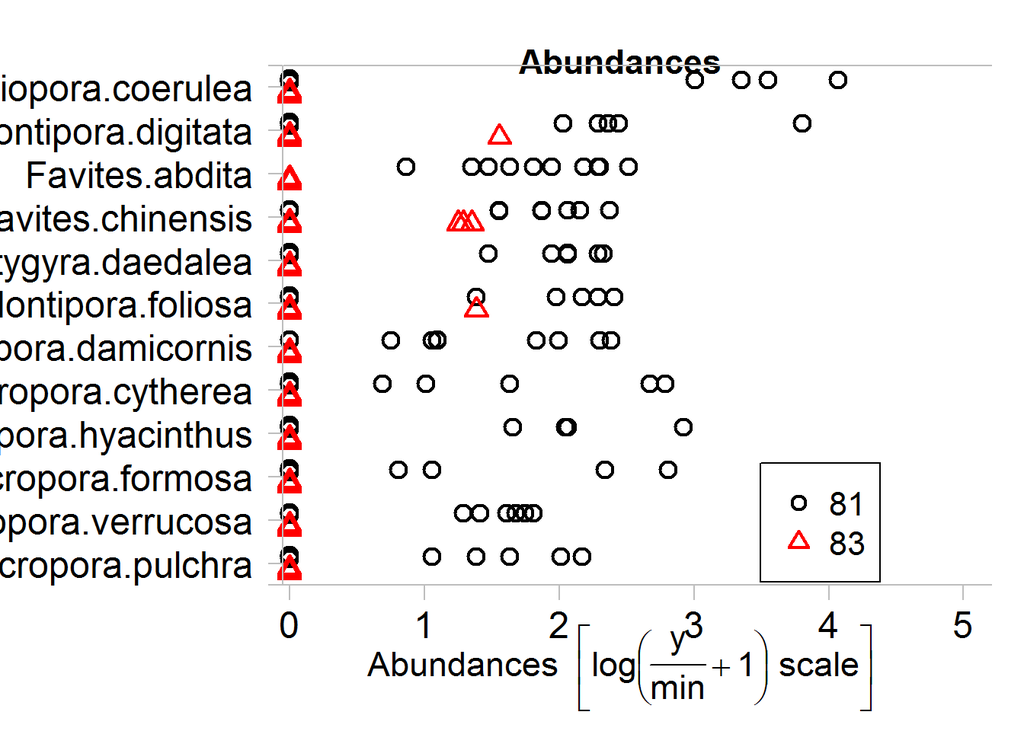

```r
plot(coverDat~time)
```

This function produces lots of subplots (up to 12 by default) and it won’t work if the window is too small (so resize it if error). The number of species that are plotted, and which ones, can be changed (see `?plot.mvabund`).

Note the striking pattern - by 1983, nearly all the coral died!

Now look at the mean-variance plot

```
## using grouping variable time 18 mean values were 0 and could
##                                      not be included in the log-plot
## using grouping variable time 18 variance values were 0 and could not
##                                      be included in the log-plot
```

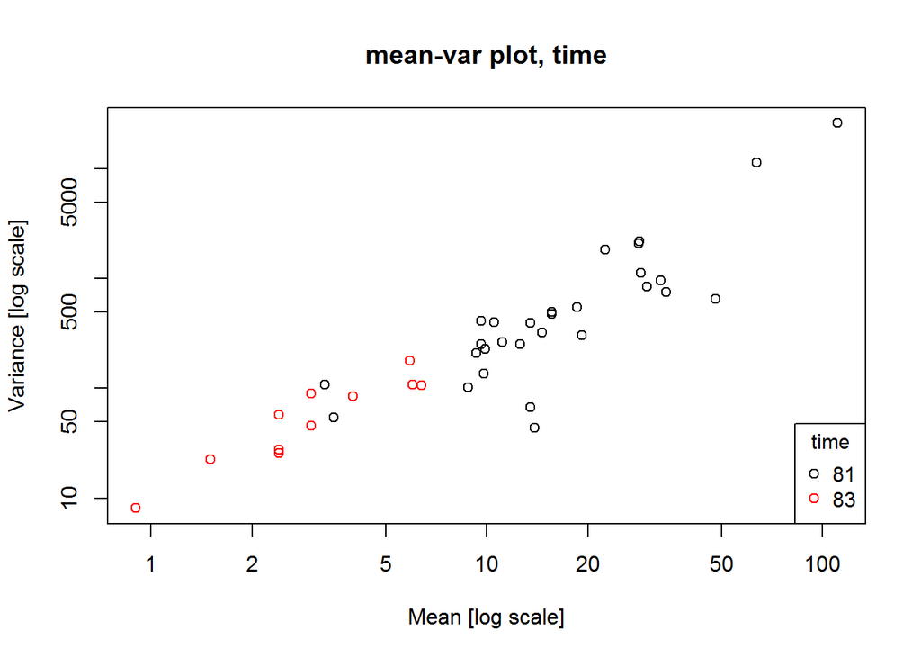

```r
meanvar.plot(coverDat~time,legend=T)
```

As the mean increases, so does the variance. Variance ranges over a factor of >1,000. (Even more variation than this is not unusual.) Also note there are heaps of points not shown: mean=0, var=0.

Does transformation fix the problem?

```
## using grouping variable time 18 mean values were 0 and could
##                                      not be included in the log-plot
## using grouping variable time 18 variance values were 0 and could not
##                                      be included in the log-plot
```

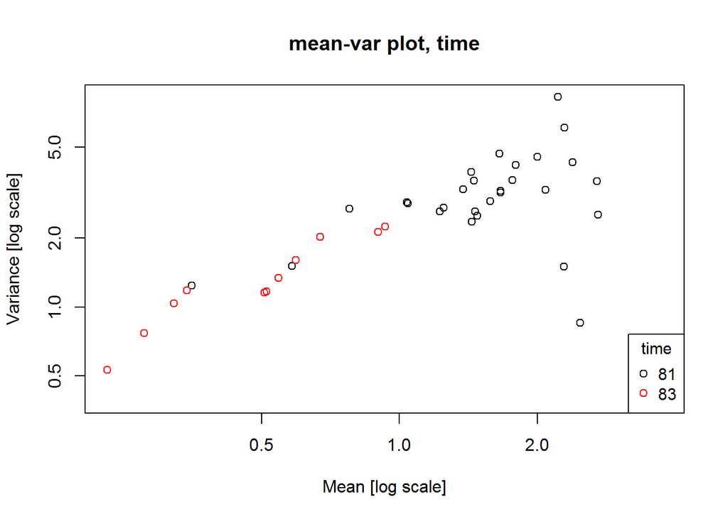

```r
meanvar.plot(log(coverDat+1)~time,legend=T)
```

```
## Overlapping points were shifted along the y-axis to make them visible.
## Only the variables Heliopora.coerulea, Montipora.digitata, Favites.abdita, Favites.chinensis, Platygyra.daedalea, Montipora.foliosa, Pocillopora.damicornis, Acropora.cytherea, Acropora.hyacinthus, Acropora.formosa, Pocillopora.verrucosa, Acropora.pulchra were included in the plot
## (the variables with highest total abundance).
```

[figure not shown]

```r
plot(coverDat~time)
```

No. You always get points trailing off towards the bottom left (and there are always points at mean=0, var=0). The problem is all the zeros in the data, which is typical of this type of data, but it means you can’t transform to stabilise variances.

# “no frills” manyglm analysis

We will analyse the coral data using the `manyglm` function.

Our first problem we have is that `manyglm` only handles counts (neg binomial, poisson, binomial) not cover. so let’s start by converting to presence-absence data, which `manyglm` can handle

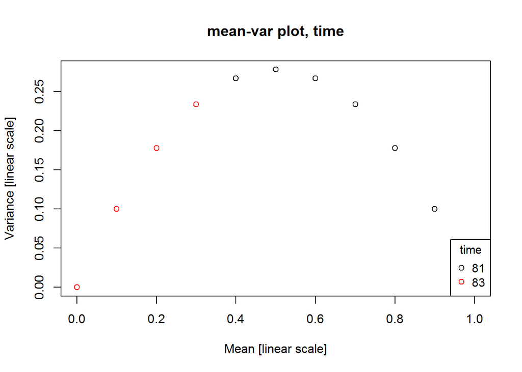

```r
presDat = coverDat
presDat[presDat>1] = 1 #turning into pres/abs
meanvar.plot(presDat~time,legend=T,log="")
```

Note the quadratic up-down thing - pres/absence data ALWAYS looks like this -> it (marginally) follows a binomial distribution.

We would like to fit GLMs to the presence-absence data. But there are two things to think about when specifying a GLM, the family (in this case binomial) and the link function. By default, `manyglm` will assume you have counts and want to fit a negative binomial regression with a log-link. Note this is quite different to the default behaviour of the `glm` function!

For presence-absence data, usually people use the logit link function (“logistic regression”) but perhaps a more sensible default for presence-absence data is the complementary log-log link (`"cloglog"`). The cloglog link is what you would get if you truncate Poisson counts to presence-absence and the mean count was a log-linear function of predictors. Sure maybe we don’t have Poisson, or log-linearity, but this is a more sensible default than logit (which has no such motivation for truncated counts).

Fit a model assuming data follow a complementary log-log link, main effects of time and transect ID

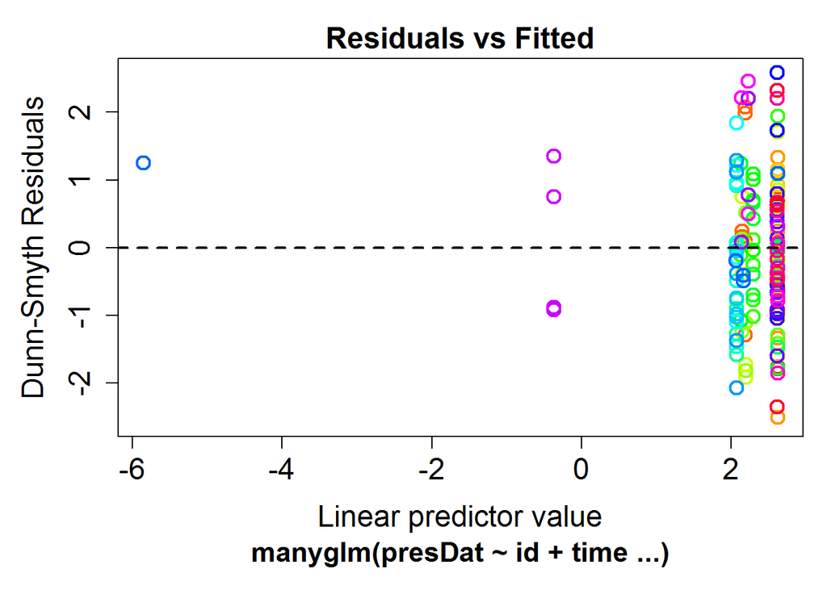

```r
ft=manyglm(presDat~id+time,family="cloglog")
plot(ft)
```

Why main effects for time and transect ID: because the same transects were sampled on multiple occasions so we want to try to account for this in the model (transect is a “block” variable).

If you had wanted to go with logistic regression instead you could have used `family="binomial"`.

Try fitting again to see how residuals change a bit:

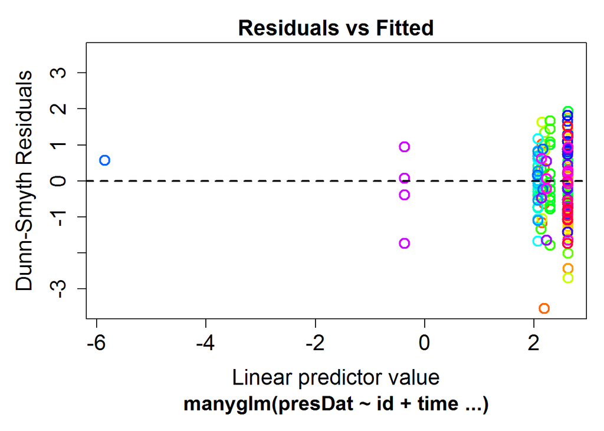

```r
plot(ft)
```

Notice things changed a bit, because we are using Dunn-Smyth residuals, which have some randomness (“jittering”) in them. Always a good idea to plot more than once, especially if you think you see some structure in the model, to check if it was just random values playing tricks on you.

Now do an anova, we care mostly about time effect:

```r
an = anova(ft,show.time="all",p.uni="adjusted")
```

```
## Resampling begins for test 1.
##  Resampling run 0 finished. Time elapsed: 0.00 minutes...
##  Resampling run 100 finished. Time elapsed: 0.01 minutes...
##  Resampling run 200 finished. Time elapsed: 0.02 minutes...
##  Resampling run 300 finished. Time elapsed: 0.03 minutes...
##  Resampling run 400 finished. Time elapsed: 0.04 minutes...
##  Resampling run 500 finished. Time elapsed: 0.05 minutes...
##  Resampling run 600 finished. Time elapsed: 0.07 minutes...
##  Resampling run 700 finished. Time elapsed: 0.08 minutes...
##  Resampling run 800 finished. Time elapsed: 0.09 minutes...
##  Resampling run 900 finished. Time elapsed: 0.10 minutes...
## Resampling begins for test 2.
##  Resampling run 0 finished. Time elapsed: 0.00 minutes...
##  Resampling run 100 finished. Time elapsed: 0.01 minutes...
##  Resampling run 200 finished. Time elapsed: 0.02 minutes...
##  Resampling run 300 finished. Time elapsed: 0.02 minutes...
##  Resampling run 400 finished. Time elapsed: 0.03 minutes...
##  Resampling run 500 finished. Time elapsed: 0.04 minutes...
##  Resampling run 600 finished. Time elapsed: 0.05 minutes...
##  Resampling run 700 finished. Time elapsed: 0.06 minutes...
##  Resampling run 800 finished. Time elapsed: 0.07 minutes...
##  Resampling run 900 finished. Time elapsed: 0.07 minutes...
## Time elapsed: 0 hr 0 min 11 sec
```

```r
print(an$table)
```

```
##             Res.Df Df.diff      Dev Pr(>Dev)
## (Intercept)     19      NA       NA       NA
## id              10       9 308.2598    0.588
## time             9       1 352.1043    0.001
```

Significant effect of time. (No kidding. I mean nearly all the coral died!)

If you have a bigger dataset, it takes longer. Could beat this by: getting rid of rare species; parallelising and combining results; doing initial analysis with less resamples, eg `nBoot=25`; going to lunch.

Now we want to dig a little deeper to find out where the pattern with year is strongest.

Which are the “top 10” species in terms of change with time?

```r
s = sort(an$uni.test[3,],decreasing=T,index.return=T)[1:10]
# an$uni.test stores univariate test stats, 3rd row has change in deviance due to time
s$ix[1:10] # the column numbers of the "top 10" most impacted spp
```

```
##  [1] 25  6  1 11  2 27  8  3  5  9
```

```r
dimnames(presDat)[[2]][s$ix[1:10]] #the names of the top 10 spp
```

```
##  [1] "Favites.abdita"         "Acropera.aspera"
##  [3] "Pocillopora.damicornis" "Acropora.diversa"
##  [5] "Pocillopora.verrucosa"  "Platygyra.daedalea"
##  [7] "Acropora.cytherea"      "Acropora.bruegemanni"
##  [9] "Acropora.splendida"     "Acropora.pulchra"
```

```
## Overlapping points were shifted along the y-axis to make them visible.
```

```
##
##  PIPING TO 2nd MVFACTOR
```

```
## Only the variables Favites.abdita, Acropera.aspera, Pocillopora.damicornis, Acropora.diversa, Pocillopora.verrucosa, Platygyra.daedalea, Acropora.cytherea, Acropora.bruegemanni, Acropora.splendida, Acropora.pulchra were included in the plot (user selected).
```

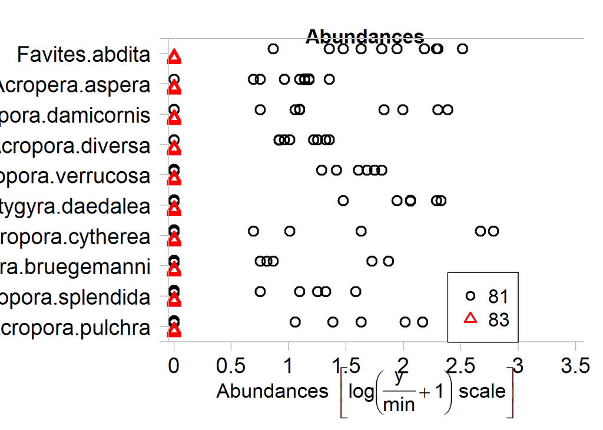

```r
plot(coverDat~time,var.subset=s$ix[1:10])
```

Here is a plot of the top 10. Notice all the circles on the right and trangles on the left - in each case, a spp present at most transects has disappeared from all in 1983.

Percentage of change in deviance due to this “top ten”:

```r
sum(an$uni.test[3,s$ix[1:10]]) / sum(an$uni.test[3,])
```

```
## [1] 0.5275704
```

About 53% of change in deviance is due to these ten, so we are missing part of the story if we focus just on these 10 species. (The part of the story we are missing is that the other 19 spp mostly disappeared too!)

You can look at coefficients and their se’s too, but in this case, that is pretty meaningless as most spp just went to zero.

# manyany analysis

`manyglm` only fits a few common GLM’s, you can get the rest using the manyany function. It can (in principle) take pretty much any univariate model (that has `predict` and `logLik` functions). The downside is that `manyany` is MUCH slower than `manyglm`. Take lunch and then a siesta.

In `manyany` you have to first specify your fitting function (`"glm"`, `"gam"`, `"glmer"`, …) next you specify a matrix or mvabund object with the response in it. Then everything else. But you need to have a data argument with all your predictors in it. For details see the help file, `?manyany`

e.g. to fit the same model as above but using `manyany`:

```r
X = data.frame(id=id,time=time)
ftAny = manyany("glm", presDat, presDat~id+time, family=binomial("cloglog"), data=X)
ftNullAny = manyany("glm", presDat, presDat~id, family=binomial("cloglog"), data=X)
anova(ftNullAny,ftAny)
```

```
##
##               LR Pr(>LR)
## sum-of-LR 352.12  < 0.01 **
## ---
## Signif. codes:  0 '***' 0.001 '**' 0.01 '*' 0.05 '.' 0.1 ' ' 1
```

Notice that we needed to fit two models in order to do an anova call using manyany - it wants to know what the null and the alternative models are.

Notice also that the default nBoot is now 99 not 999. Not because we think 99 is sufficient, just because things are so much slower and we don’t want a default analysis to tak overnight to give you an answer. You should change this to 999 to publish.

Note that this produces pretty much the same results, but takes heaps longer!

### Different stuff you can do with the manyany function

**Compositional models**: you can test for changes in relative not absolute aboundance. This is done by adding a “row effect” to the model to account for changes in abundance due to the row you are on (controlling for variation in total abundance). Other packages (PRIMER etc) are not good at doing composition.

```r
ftCAny = manyany("glm", presDat, presDat~id+time, family=binomial("cloglog"), data=X, composition=TRUE)
ftCNullAny = manyany("glm", presDat, presDat~id, family=binomial("cloglog"), data=X, composition=TRUE)
anova(ftCNullAny,ftCAny,nBoot=9)
```

```
##
##               LR Pr(>LR)
## sum-of-LR 432.52     0.2
```

You need a lot more than 9 resamples for a proper test, but you would need to go for coffee! I have thoughts on how to make this faster but haven’t tested it out yet.

**More link functions**: you can use anything from glm that is not yet in manyglm.

```r
ftProbit = manyany("glm", presDat, presDat~id+time, family=binomial("probit"),
                   data=X,composition=TRUE)
```

**More families**: for cover or biomass data, you could try using the Tweedie distribution:

```r
library(statmod)
library(tweedie)
ftTw = manyany("glm", coverDat, y~id+time, family=tweedie(var.power=1.5, link.power=0),
               var.power=1.5, data=X, composition=TRUE)
```

This takes a lot longer than it aught to, Tweedie code can be a bit weird.

You can also fit models for **ordinal data** using the manyany function in combination with the `clm` function from the `ordinal` package.

**Fit a GAM**: for example, using the spider data. But note that this is “data-hungry” so not worth much if you don’t have lots of observations

**Mixed effects models**: can be fitted via lme4, but no testing via anova function as yet.

**Block resampling**: in the `manyany` call you can use the argument `block` to specify a block factor used to resample blocks of rows instead of resampling individual rows. This can be used for repeated measures (to resample within blocks only) or to fit trait models.

# Trait modelling using traitglm

### What for?

Often ecologists collect data (especially abundance or presence-absence data) simultaneously across many taxa, with the intention of studying what occurs where (and why). Trait modelling focusses on the why - methods to help us move towards a functional explanation of community abundances. McGill et al (2006) and Shipley (2010) argue passionately for the need for this.

A common strategy in any field looking at “why” is to look for predictor variables that can explain the response. In the case of studying why some taxa are abundant at a site while others are not, the relevant predictors are species traits. These come in a matrix, different traits in different columns, different taxa in different rows.

Here is a schematic diagram (from Warton et al 2015) describing how trait modelling fits in with other things you might know about - SDM, multivariate analysis…

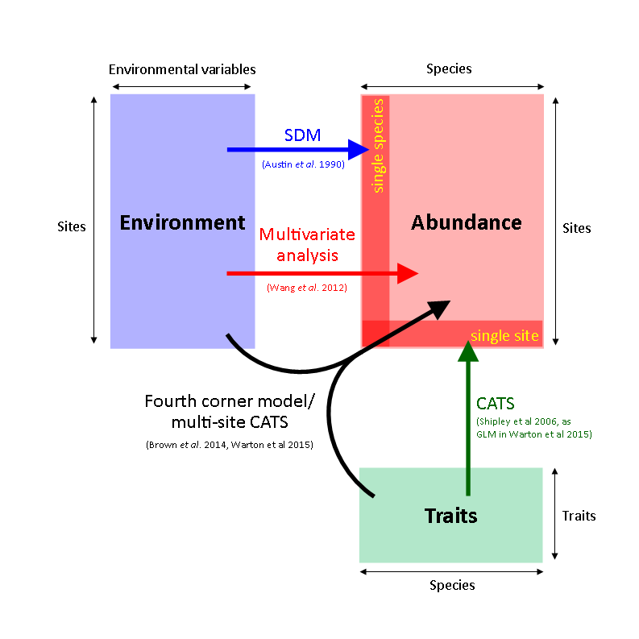

Basically we are just adding an extra type of predictor to the model (Traits). As in the following example.

## Example - ant abundances in Eucalypt forests

Gibb et al (2015) sampled at 30 sites, and ant abundances across these sites form a matrix (different sites in different rows, different species in different columns). There are predictors across sites (“environmental variables”), mostly to do with leaf litter and plant communities, and a third matrix consists of morphological measurements of each species (“species traits”). We would like to study how the abundances vary across sites and taxa as a function of environment and traits. Or more to the point, which traits best explain variation across taxa in their environmental response.

(a) Fourth corner problem

(b) Fourth corner regression model

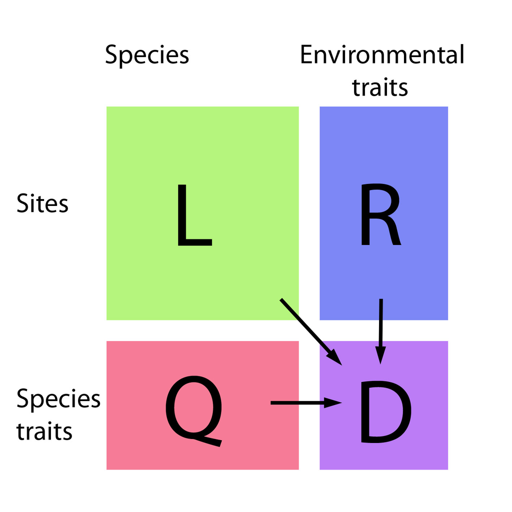

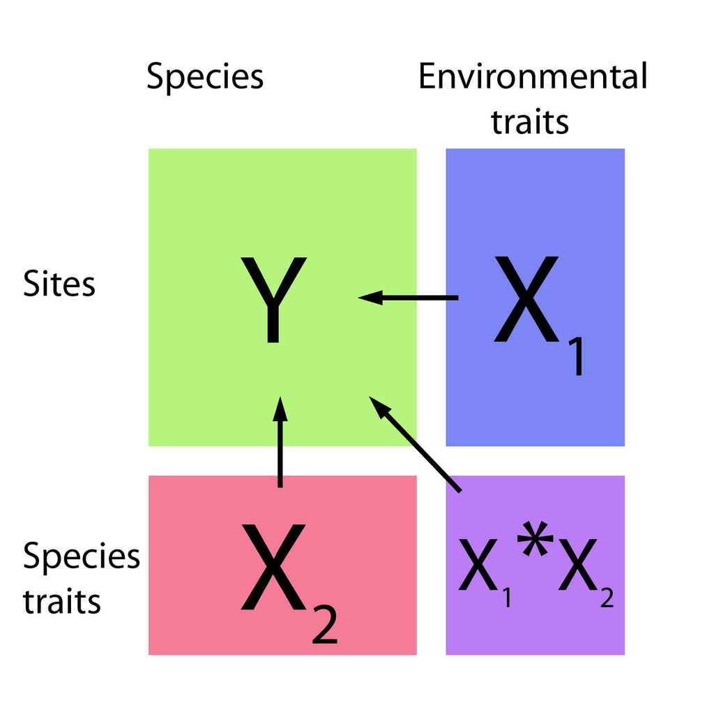

But the problem is more naturally understood using regression (as in Brown et al 2014), where the goal is to predict abundance, and we have two types of predictors - environment and trait. What we are most interested in is the interaction between environmental variables and traits (because this tells us how environmental response varies as traits vary). The env*trait interaction coefficients that arise in such a model can be understood as the fourth corner matrix. This is conceptualised in (b) above (which comes from Fig 1 from Brown et al 2014):

Fourth corner models can be fitted in the `mvabund` package using the `traitglm` function. It takes three arguments: `L`; `R`; and `Q`, and uses these to construct a regression model for abundance (`L`) which by default is a function of additive terms for each variable in `R` and `Q`, quadratic terms for any continuous covariates (such as Weber’s length), and interaction terms between environmental and trait variables. These interactions are what we really care about (how environmental response changes as traits change). All variables are standardised by default. You can override the defaults by using the `formula` argument to specify your own model.

The data need to be entered in such a way that the rows of `L` and `R` must match (and correspond to the sites sampled), and the columns of `L` must match the rows of `Q` (and correspond to the different taxa observed). This means that as compared to the above diagram, `Q` needs to be turned on its side, as in the `antTraits` dataset.

```r
data(antTraits)
ft=traitglm(antTraits$abund,antTraits$env,antTraits$traits)
ft$fourth #print fourth corner terms
```

```
##                Bare.ground Canopy.cover Shrub.cover Volume.lying.CWD
## Femur.length  -0.005345114  -0.03372640 -0.08466868      0.166704473
## No.spines     -0.044762960  -0.05617178 -0.08895730     -0.119947323
## Pilosity1      0.106170621   0.27895627  0.21017965      0.321139481
## Pilosity2      0.156827335   0.21664390  0.24303431      0.273490092
## Pilosity3      0.114907563  -0.06121788  0.14341268      0.198330954
## Polymorphism1  0.104301092   0.05480562  0.03436300     -0.019276849
## Polymorphism2  0.049544180   0.03579859  0.03286363     -0.009168761
## Webers.length  0.088389978   0.08653766 -0.04842004     -0.014818163
##               Feral.mammal.dung
## Femur.length        -0.02590566
## No.spines            0.03960764
## Pilosity1            0.03909514
## Pilosity2            0.04365594
## Pilosity3            0.06744810
## Polymorphism1        0.07903784
## Polymorphism2        0.02906444
## Webers.length       -0.05484184
```

Note that parameters should be interpreted (like in multiple regression) as describing the *conditional* effect, that is, the effect after controlling for all other predictors in the model. So for example a `femur*volume` interaction term only shows up if there is an itneraction between `femur length` and `volume` of lying wood, after accounted for any potential effects of `pilosity`, `Webers length`, `polymorphism`, `Canopy cover`, …

You can change the type of model being fitted by `traitglm` using the `method` argument and other usual arguments such as `family`. The default method used for the fit is a `manyglm` model, which enables use of the `anova` function for resampling-based hypothesis testing for a environment*trait interaction. As before, `manyglm` assumes unless told otherwise that you have counts and fits a negative binomial regression. If you had presence/absence for example you could add the argument `family="binomial"` or `family="cloglog"` to your `traitglm` call.

There is an optional `formula` argument so you can control the exact model of trait and environmental variables that is fitted.

```r
ft2=traitglm(antTraits$abund,antTraits$env,antTraits$traits,formula=~poly(Shrub.cover,2)+poly(Volume.lying.CWD,2)+poly(Femur.length,2)+Pilosity+Shrub.cover:Femur.length+Shrub.cover:Pilosity+Volume.lying.CWD:Femur.length)
ft2$fourth #print fourth corner terms
```

```
##                                     coef
## Shrub.cover:Femur.length      -0.2658065
## Pilosity1:Shrub.cover          0.1178432
## Pilosity2:Shrub.cover          0.1844171
## Pilosity3:Shrub.cover          0.1828808
## Femur.length:Volume.lying.CWD 33.4938853
```

With a user-entered formula the fourth corner coefficients are printed in a vector not a matrix, because using a formula, it might not be the case that all possible interactions between environmental and trait variables are include in the model.

You can also control whether or not row effects are include in the model using `composition`, to make the model compositional (i.e. focussing on relative abundance in samples, not absolute abundance, like in `manyany`), and whether or not to include column effects using `col.intercepts`. Default is `composition=FALSE`, `col.intercepts=TRUE`, i.e. column effects but no row effects, as for `manyglm` and `manyany`.

```r
ftRow=traitglm(antTraits$abund,antTraits$env,antTraits$traits,formula=~poly(Shrub.cover,2)+poly(Volume.lying.CWD,2)+poly(Femur.length,2)+Pilosity+Shrub.cover:Femur.length+Shrub.cover:Pilosity+Volume.lying.CWD:Femur.length,composition=TRUE)
ftRow$fourth #print fourth corner terms
```

```
##                                     coef
## Shrub.cover:Femur.length      -0.2863269
## Pilosity1:Shrub.cover          0.1111436
## Pilosity2:Shrub.cover          0.1731233
## Pilosity3:Shrub.cover          0.1629477
## Femur.length:Volume.lying.CWD 31.1553000
```

If you include row effects you don’t actually need main effects for environmental variables, because the row effects act as a main effect on sites already. Similarly, you don’t need main effects on traits if you have column effects in the model. So we could have fitted the exact same model using:

```r
ftRow2=traitglm(antTraits$abund,antTraits$env,antTraits$traits,formula=~Shrub.cover:Femur.length+Shrub.cover:Pilosity+Volume.lying.CWD:Femur.length,composition=TRUE)
ftRow2$fourth #note these are the same as last time
```

```
##                                     coef
## Shrub.cover:Femur.length      -0.2863173
## Shrub.cover:Pilosity1          0.1111440
## Shrub.cover:Pilosity2          0.1731245
## Shrub.cover:Pilosity3          0.1629482
## Femur.length:Volume.lying.CWD 31.1596223
```

The `anova` function can be used to test for the significance of the fourth corner terms in the model. It takes a long time to run though so I’ll sub-sample the data first, to just the species found at more than 20% of sites, and a reduced number of predictor variables:

```r
abSum = apply(antTraits$abund>0,2,mean) # stores the proportion of values that are non-zero for each species.
ab = antTraits$abund[,abSum>0.2] # just keep columns of $abund that are more than 20% presence
tr = antTraits$traits[abSum>0.2,] # and make sure that change is also made to rows of the traits data frame.

# now fit the fourth corner model, only as a function of a couple of traits and env variables:
ftSmall=traitglm(ab,antTraits$env[,1:3],data.frame(tr$Pilosity,tr$Femur))
anova(ftSmall)
```

```
## Using block resampling...
## Resampling begins for test 1.
##  Resampling run 0 finished. Time elapsed: 0.00 minutes...
## Time elapsed: 0 hr 0 min 10 sec
```

```
## Analysis of Deviance Table
##
## Model 1: l ~ V1 + sppCamponotus.claripes + sppCamponotus.consobrinus + sppCamponotus.nigriceps + sppCamponotus.nigroaeneus + sppHeteroponera.sp..A + sppIridomyrmex.bicknelli + sppIridomyrmex.dromus + sppIridomyrmex.mjobergi + sppIridomyrmex.purpureus + sppIridomyrmex.rufoniger + sppIridomyrmex.su…
##     sppNotoncus.ectatommoides + sppNylanderia.sp..A + sppPheidole.sp..A + sppPheidole.sp..B + sppPheidole.sp..E + sppPolyrhachis.sp..A + sppRhytidoponera.metallica.sp..A + sppRhytidoponera.sp..B + sppStigmacros.sp..A + sppTapinoma.sp..A + sppTetramorium.sp..A + Bare.ground + Canopy.cover + Shrub.…
## Model 2: l ~ V1 + sppCamponotus.claripes + sppCamponotus.consobrinus + sppCamponotus.nigriceps + sppCamponotus.nigroaeneus + sppHeteroponera.sp..A + sppIridomyrmex.bicknelli + sppIridomyrmex.dromus + sppIridomyrmex.mjobergi + sppIridomyrmex.purpureus + sppIridomyrmex.rufoniger + sppIridomyrmex.su…
##     sppNotoncus.ectatommoides + sppNylanderia.sp..A + sppPheidole.sp..A + sppPheidole.sp..B + sppPheidole.sp..E + sppPolyrhachis.sp..A + sppRhytidoponera.metallica.sp..A + sppRhytidoponera.sp..B + sppStigmacros.sp..A + sppTapinoma.sp..A + sppTetramorium.sp..A + Bare.ground + Canopy.cover + Shrub.…
##     Canopy.cover.tr.Pilosity3 + Canopy.cover.tr.Femur + Shrub.cover.tr.Pilosity1 + Shrub.cover.tr.Pilosity2 + Shrub.cover.tr.Pilosity3 + Shrub.cover.tr.Femur
##
## Multivariate test:
##                           Res.Df Df.diff   Dev Pr(>Dev)
## Main effects only            922
## env:trait (fourth corner)    910      12 29.41     0.06 .
## ---
## Signif. codes:  0 '***' 0.001 '**' 0.01 '*' 0.05 '.' 0.1 ' ' 1
## Arguments: P-value calculated using 99 resampling iterations via PIT-trap block resampling (to account for correlation in testing).
```

We can see from these results that there is marginal evidence of a environment:trait interaction term, i.e. these traits explain a marginally significant amount of the variation in environmental response across species.

The formula that is displayed in `anova` output is butt-ugly at the moment: instead of just saying `spp` for the column (or species) effect that is in the model, it lists all the indicator variables. Hopefully we’ll fix that in the next package update.

The idea of using resampling-based inference in a regression context to test for fourth corner interactions was first illustrated in Warton et al (2015), under the guise of multi-site CATS regression. The `anova.traitglm` function uses “block resampling”, resampling sites but keeping all species from a site together in the resample. Block resampling by site ensures that we can make inferences that are valid if the abundances can be assumed to be *independent across sites*, even though we know that the abundances are not independent across species. Resampling means that it can take a while though. If you sampled clusters of independent data (e.g. repeated measures) you can also include a `block` argument in your `anova.traitglm` call in order to block resample by clusters of rows instead of by rows.

Note the number of bootstrap resamples used - only 99 by default, which is only correct to within 2% for a P-value near 0.05. As for `anova.manyany`, the reason only 99 resamples are used by default is that this takes a fair while to run, but you should repeat with `nBoot=999` when you want a more accurate P-value, after a test run to see exactly how long you will have to wait! (in this case, about 80 seconds)

### GLMs and fourth corner models using a LASSO penalty

A recent addition to the `mvabund` package is some functions for fitting GLMs using a LASSO penalty, the main one being the `glm1path` function. This simplifies interpretation because it automatically does model selection, setting to zero any interaction coefficients that don’t help reduce BIC:

```r
ft1=traitglm(antTraits$abund,antTraits$env,antTraits$traits,method="glm1path")
ft1$fourth #notice LASSO penalty has shrunk many interactions to zero
```

```
##               Bare.ground Canopy.cover Shrub.cover Volume.lying.CWD
## Femur.length   0.00000000  0.000000000 -0.05653626       0.10635948
## No.spines     -0.02193309 -0.003940441 -0.03615544      -0.08549197
## Pilosity0     -0.04688064 -0.076900343 -0.07239145      -0.12969223
## Pilosity1      0.00000000  0.036098724  0.00000000       0.00000000
## Pilosity2      0.01457037  0.000000000  0.03473728       0.00000000
## Pilosity3      0.03314056 -0.158031996  0.00000000       0.00000000
## Polymorphism0 -0.03477743 -0.001193911  0.00000000       0.00000000
## Polymorphism1  0.03887527  0.005790553  0.00000000       0.00000000
## Polymorphism2  0.00000000  0.000000000  0.00000000       0.00000000
## Webers.length  0.05834639  0.057169217 -0.02282845       0.00000000
##               Feral.mammal.dung
## Femur.length       0.0000000000
## No.spines          0.0167645908
## Pilosity0          0.0000000000
## Pilosity1          0.0000000000
## Pilosity2          0.0000000000
## Pilosity3          0.0004473121
## Polymorphism0      0.0000000000
## Polymorphism1      0.0000000000
## Polymorphism2      0.0000000000
## Webers.length     -0.0188204072
```

Notice all the zeros in the fourth corner matrix now.

There is also a `cv.glm1path` function, to use cross-validation to choose the best model, but the standard error calculation is giving some funny answers at the moment so check with David if you are going to use it with the 1se rule.

To construct a pretty picture of the fourth corner coefficients, along the lines of Gibb et al (2015):

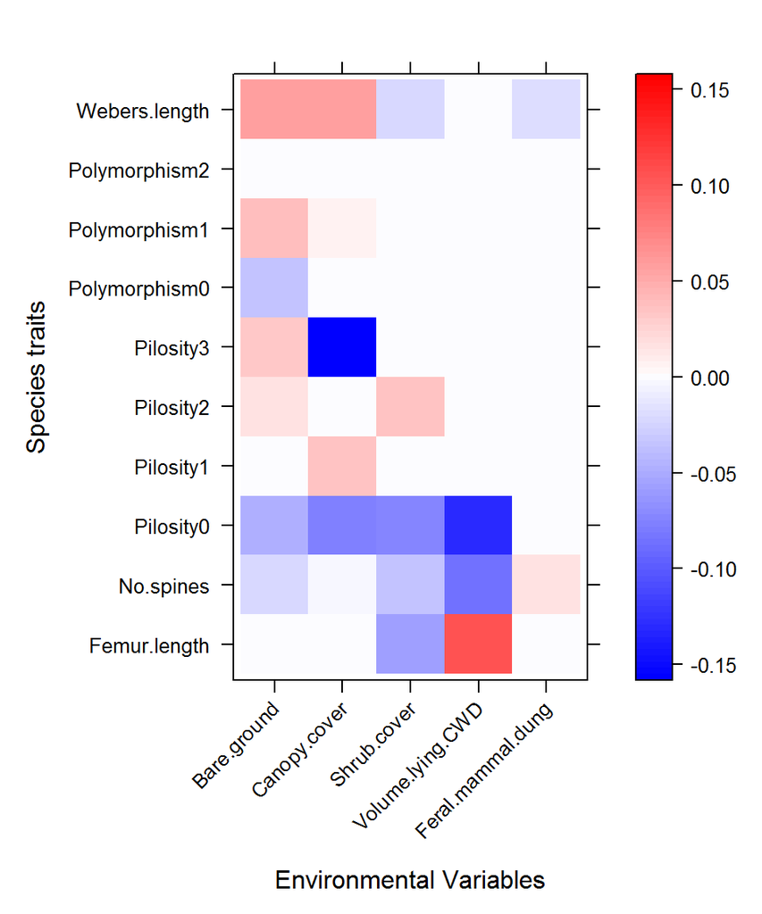

```r
library(lattice)
a        = max( abs(ft1$fourth.corner) )
colort   = colorRampPalette(c("blue","white","red"))
plot.4th = levelplot(t(as.matrix(ft1$fourth.corner)), xlab="Environmental Variables",
 ylab="Species traits", col.regions=colort(100), at=seq(-a, a, length=100),
 scales = list( x= list(rot = 45)))
print(plot.4th)
```

### Fitting a single multi-species SDM

You can also use this function to fit a single predictive model for all species at all sites, assuming different environmental response for difference species, but not attempting to explain these using traits. Kind of like `manyglm` but all in a single model, and maybe using a LASSO for estimation. This can be understood as like a multivariate SDM. This can be done by using `traitglm` function without a trait argument, because by default, a species ID factor is used as `Q`.

```r
ftspp1=traitglm(antTraits$abund,antTraits$env,method="glm1path")
```

```
## No traits matrix entered, so will fit SDMs with different env response for each spp
```

```r
ftspp1$fourth #notice LASSO penalty has shrunk many interactions to zero
```

```
##                                        Bare.ground Canopy.cover
## names.L.Amblyopone.australis           0.000000000  0.000000000
## names.L.Aphaenogaster.longiceps        0.000000000  0.195903772
## names.L.Camponotus.cinereus.amperei    0.000000000  0.051089268
## names.L.Camponotus.claripes            0.085404350  0.101102800
## names.L.Camponotus.consobrinus         0.053094170 -0.046531404
## names.L.Camponotus.nigriceps           0.000000000  0.112896362
## names.L.Camponotus.nigroaeneus         0.093879869  0.074060218
## names.L.Cardiocondyla.nuda.atalanta   -0.010988317  0.000000000
## names.L.Crematogaster.sp..A            0.000000000  0.036135506
## names.L.Heteroponera.sp..A             0.000000000  0.000000000
## names.L.Iridomyrmex.bicknelli          0.029544801 -0.105223246
## names.L.Iridomyrmex.dromus             0.036160843  0.000000000
## names.L.Iridomyrmex.mjobergi          -0.030370598  0.000000000
## names.L.Iridomyrmex.purpureus          0.016079976  0.000000000
## names.L.Iridomyrmex.rufoniger          0.000000000 -0.125993541
## names.L.Iridomyrmex.suchieri           0.000000000 -0.057124677
## names.L.Iridomyrmex.suchieroides       0.000000000 -0.031790430
## names.L.Melophorus.sp..E               0.012687320  0.000000000
## names.L.Melophorus.sp..F              -0.013298385 -0.032551264
## names.L.Melophorus.sp..H              -0.040156289  0.000000000
## names.L.Meranoplus.sp..A               0.000000000 -0.037315624
## names.L.Monomorium.leae                0.000000000  0.080980647
## names.L.Monomorium.rothsteini         -0.059078261 -0.151110963
## names.L.Monomorium.sydneyense         -0.009400791 -0.016848224
## names.L.Myrmecia.pilosula.complex      0.000000000  0.000000000
## names.L.Notoncus.capitatus            -0.021835901  0.047607685
## names.L.Notoncus.ectatommoides         0.000000000  0.000000000
## names.L.Nylanderia.sp..A               0.000000000 -0.111945793
## names.L.Ochetellus.glaber              0.000000000  0.000000000
## names.L.Paraparatrechina.sp..B         0.000000000  0.137431642
## names.L.Pheidole.sp..A                 0.000000000  0.000000000
## names.L.Pheidole.sp..B                 0.000000000  0.079300183
## names.L.Pheidole.sp..E                -0.006205572  0.000000000
## names.L.Pheidole.sp..J                 0.000000000  0.000000000
## names.L.Polyrhachis.sp..A              0.000000000  0.013672230
## names.L.Rhytidoponera.metallica.sp..A -0.011215687 -0.020809462
## names.L.Rhytidoponera.sp..B           -0.020977054  0.000000000
## names.L.Solenopsis.sp..A               0.000000000  0.000000000
## names.L.Stigmacros.sp..A               0.000000000  0.058630996
```

[output cut: 71 more lines]

```
## names.L.Notoncus.ectatommoides             -0.015422250
## names.L.Nylanderia.sp..A                   -0.017632939
## names.L.Ochetellus.glaber                   0.000000000
## names.L.Paraparatrechina.sp..B              0.000000000
## names.L.Pheidole.sp..A                      0.000000000
## names.L.Pheidole.sp..B                     -0.009424855
## names.L.Pheidole.sp..E                      0.000000000
## names.L.Pheidole.sp..J                      0.042361417
## names.L.Polyrhachis.sp..A                   0.000000000
## names.L.Rhytidoponera.metallica.sp..A       0.000000000
## names.L.Rhytidoponera.sp..B                 0.000000000
## names.L.Solenopsis.sp..A                    0.000000000
## names.L.Stigmacros.sp..A                    0.000000000
## names.L.Tapinoma.sp..A                      0.000000000
## names.L.Tetramorium.sp..A                   0.027725589
```

And we can see from this which species are responding to the environmental gradient and how.

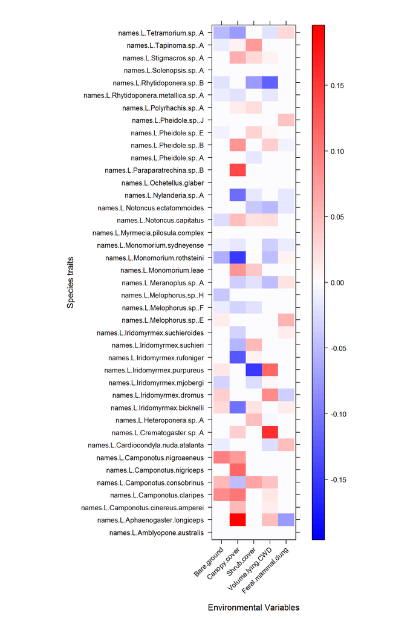

```r
library(lattice)
a        = max( abs(ftspp1$fourth.corner) )
colort   = colorRampPalette(c("blue","white","red"))
plot.spp = levelplot(t(as.matrix(ftspp1$fourth.corner)), xlab="Environmental Variables",
 ylab="Species traits", col.regions=colort(100), at=seq(-a, a, length=100),
 scales = list( x= list(rot = 45)))
print(plot.spp)
```

You could actually include both traits and a spp ID factor in `Q`, if you use a LASSO penalty. This would allow species terms to “soak up” additional variation across species not explained by traits. Jamil et al (2013) argue strongly for including such a term in the model, Brown et al (2014) tried it and found it doesn’t always help the cause.

## References

Brown, A.M., Warton, D.I., Andrew, N.R., Binns, M., Cassis, G. & Gibb, H. (2014) The fourth-corner solution – using predictive models to understand how species traits interact with the environment. *Methods in Ecology and Evolution*, 5, 344-352.

Doledec, S., Chessel,D., terBraak, C.J.F.&Champely, S. (1996) Matching species traits to environmental variables: a new three-table ordination method. *Environmental and Ecological Statistics*, 3, 143-166

Gibb, H., Stoklosa, J., Warton, D.I., Brown, A.M., Andrew, N.R. & Cunningham, S.A. (2015) Does morphology predict trophic position and habitat use of ant species and assemblages? *Oecologia*, 177, 519-531

Jamil, T., Ozinga, W.A., Kleyer, M. & ter Braak, C.J. (2013) Selecting traits that explain species-environment relationships: a generalized linear mixed model approach. *Journal of Vegetation Science*, 24, 988-1000.

Legendre, P., Galzin, R. & Harmelin-Vivien, M.L. (1997) Relating behavior to habitat: solutions to the fourth-corner problem. *Ecology*, 78, 547-562.

McGill, B.J., Enquist, B.J.,Weiher, E.&Westoby,M. (2006) Rebuilding community ecology from functional traits. *Trends in Ecology and Evolution*, 20, 178-185.

Pollock, L.J., Morris, W.K. & Vesk, P.A. (2012) The role of functional traits in species distributions revealed through a hierarchical model. *Ecography*, 35, 716-725

Shipley, B., Vile, D. & Garnier, E. (2006) From plant traits to plant communities: a statistical mechanistic approach to biodiversity. *Science*, 314, 812-814.

Shipley, B. (2010) *From Plant Traits to Vegetation Structure: Chance and Selection in the Assembly of Ecological Communities*. Cambridge University Press, Cambridge. In this book, Shipley described communitry ecologists who are not using trait varibles as acting like “demented accountants”! (documenting lots of different patterns in different species without thinking about why they are different…)

Warton, D.I., Shipley, B., & Hastie, T. (2015) CATS regression – a model-based approach to studying trait-based community assembly. *Methods in Ecology and Evolution*, 6, 389-398.